## Red Wine Quality Dataset Analysis With R

##### (Udacity Data Analsysis Nanodegree)

# Donal O Farrell

#### Loading Data Set and Initial Analysis

The data-set chosen for this project was the Red Wine Quality data provided from Udacity and loaded as a CSV file.

The parameter X appears to be simply an index and there is no indication that it is ordered in any way, presumably this is to ensure a unique identifier for wines with the same characteristics.

There are multiple measures of acidity expressed and other chemical attributes expressed as float numbers. From the summary statistics, some initial observations about the typical attributes of red wine can be made:

There are no indications of the units used for the chemical constituents, probably ppm for chlorides / sulfides / sulphates though the residual sugars may be expressed as a percentage just as alcohol is.

The summary stats of the residual sugars indicate the presence of a long tail or at least outliers on the upper end of the distribution due to the higher mean and very high max value relative to the median and the quartile positions. This may be as a result of desert wines included in the data set.

Similar properties can be seen in the summary stats of alcohol percentage though the max value is far less extreme suggesting a asymmetric distribution more strongly than the presence of outliers.

Finally the quality parameter is a integer value that looks to be one of the keys variable of interest. It is a integer value ranging from 3 to 8, with a mean close to the central value of 5.6. The median is mismatched to the mean but its not clear if this is a symptom of the discrete nature of the variable.

```
## 'data.frame':    1599 obs. of  13 variables:
##  $ X                   : int  1 2 3 4 5 6 7 8 9 10 ...
##  $ fixed.acidity       : num  7.4 7.8 7.8 11.2 7.4 7.4 7.9 7.3 7.8 7.5 ...
##  $ volatile.acidity    : num  0.7 0.88 0.76 0.28 0.7 0.66 0.6 0.65 0.58 0.5 ...
##  $ citric.acid         : num  0 0 0.04 0.56 0 0 0.06 0 0.02 0.36 ...
##  $ residual.sugar      : num  1.9 2.6 2.3 1.9 1.9 1.8 1.6 1.2 2 6.1 ...
##  $ chlorides           : num  0.076 0.098 0.092 0.075 0.076 0.075 0.069 0.065 0.073 0.071 ...
##  $ free.sulfur.dioxide : num  11 25 15 17 11 13 15 15 9 17 ...
##  $ total.sulfur.dioxide: num  34 67 54 60 34 40 59 21 18 102 ...
##  $ density             : num  0.998 0.997 0.997 0.998 0.998 ...
##  $ pH                  : num  3.51 3.2 3.26 3.16 3.51 3.51 3.3 3.39 3.36 3.35 ...
##  $ sulphates           : num  0.56 0.68 0.65 0.58 0.56 0.56 0.46 0.47 0.57 0.8 ...
##  $ alcohol             : num  9.4 9.8 9.8 9.8 9.4 9.4 9.4 10 9.5 10.5 ...
##  $ quality             : int  5 5 5 6 5 5 5 7 7 5 ...
```

```
##        X          fixed.acidity   volatile.acidity  citric.acid
##  Min.   :   1.0   Min.   : 4.60   Min.   :0.1200   Min.   :0.000
##  1st Qu.: 400.5   1st Qu.: 7.10   1st Qu.:0.3900   1st Qu.:0.090
##  Median : 800.0   Median : 7.90   Median :0.5200   Median :0.260
##  Mean   : 800.0   Mean   : 8.32   Mean   :0.5278   Mean   :0.271
##  3rd Qu.:1199.5   3rd Qu.: 9.20   3rd Qu.:0.6400   3rd Qu.:0.420
##  Max.   :1599.0   Max.   :15.90   Max.   :1.5800   Max.   :1.000
##  residual.sugar     chlorides       free.sulfur.dioxide
##  Min.   : 0.900   Min.   :0.01200   Min.   : 1.00
##  1st Qu.: 1.900   1st Qu.:0.07000   1st Qu.: 7.00
##  Median : 2.200   Median :0.07900   Median :14.00
##  Mean   : 2.539   Mean   :0.08747   Mean   :15.87
##  3rd Qu.: 2.600   3rd Qu.:0.09000   3rd Qu.:21.00
##  Max.   :15.500   Max.   :0.61100   Max.   :72.00
##  total.sulfur.dioxide    density             pH          sulphates
##  Min.   :  6.00       Min.   :0.9901   Min.   :2.740   Min.   :0.3300
##  1st Qu.: 22.00       1st Qu.:0.9956   1st Qu.:3.210   1st Qu.:0.5500
##  Median : 38.00       Median :0.9968   Median :3.310   Median :0.6200
##  Mean   : 46.47       Mean   :0.9967   Mean   :3.311   Mean   :0.6581
##  3rd Qu.: 62.00       3rd Qu.:0.9978   3rd Qu.:3.400   3rd Qu.:0.7300
##  Max.   :289.00       Max.   :1.0037   Max.   :4.010   Max.   :2.0000
##     alcohol         quality
##  Min.   : 8.40   Min.   :3.000
##  1st Qu.: 9.50   1st Qu.:5.000
##  Median :10.20   Median :6.000
##  Mean   :10.42   Mean   :5.636
##  3rd Qu.:11.10   3rd Qu.:6.000
##  Max.   :14.90   Max.   :8.000
```

```
## [1] "Ratio of range of 50%-75% quantile range to 25%-50% quantile range\n      showing assymetry of distrbution, skewed towards the higher values\n      of Residual Sugar. "
```

```
##      75%
## 1.333333
```

```
## [1] "Ratio of range of 50%-75% quantile range to 25%-50% quantile \n      range showing assymetry of distrbution, skewed towards the \n      higher values of Alchohol. "
```

```
##      75%
## 1.285714
```

# Univariate Plots Section

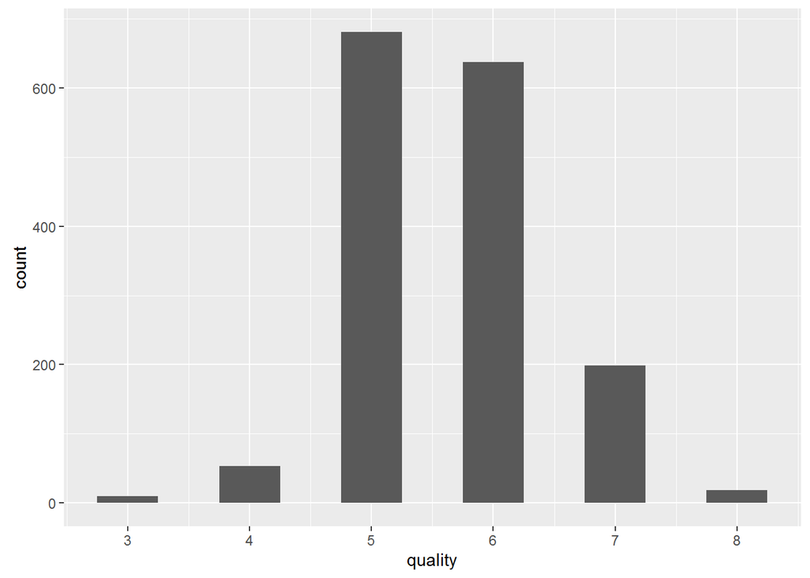

From the plot of quality above it can be seen that most red wines are of quality value 5 or 6.

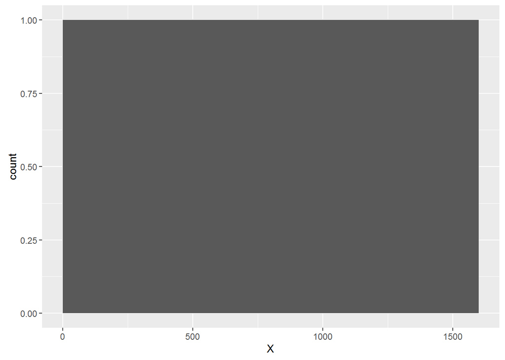

```
## [1]    1 1599
```

An initial question concerned the nature of the variable “x”, above is just confirming this is an index.

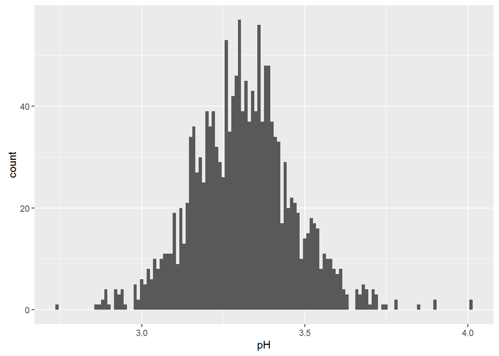

```
##    Min. 1st Qu.  Median    Mean 3rd Qu.    Max.
##   2.740   3.210   3.310   3.311   3.400   4.010
```

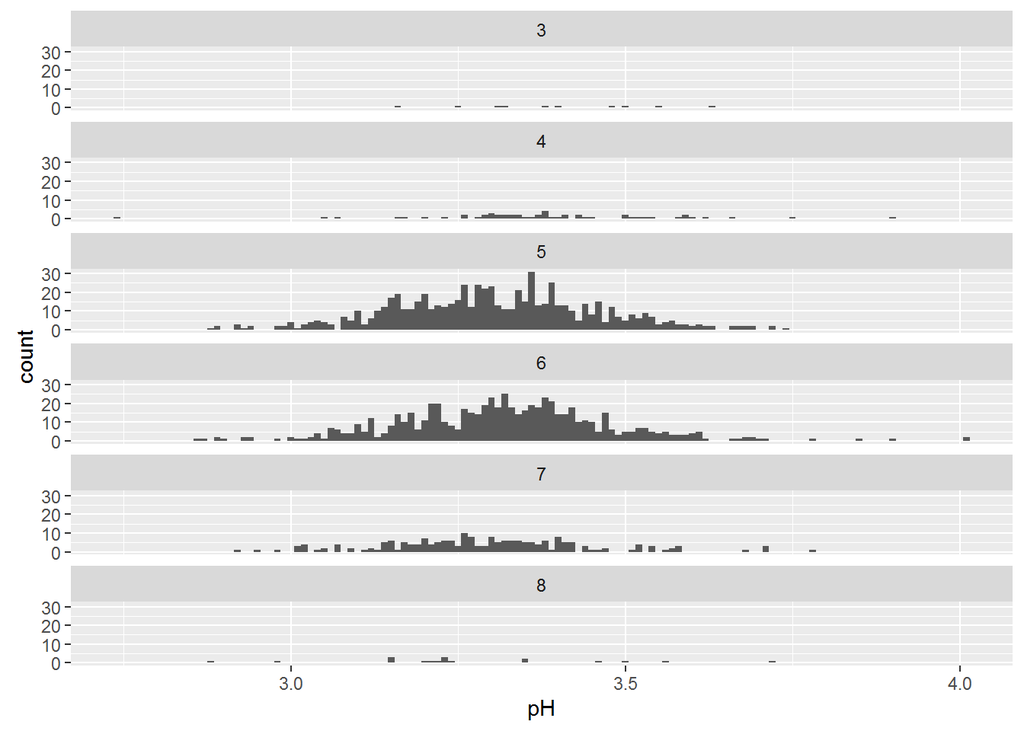

```
## [1] "Mean pH"
```

```
## # A tibble: 6 × 2
##   quality      avg
##     <int>    <dbl>
## 1       3 3.398000
## 2       4 3.381509
## 3       5 3.304949
## 4       6 3.318072
## 5       7 3.290754
## 6       8 3.267222
```

```
## [1] "Median pH"
```

```
## # A tibble: 6 × 2
##   quality median
##     <int>  <dbl>
## 1       3   3.39
## 2       4   3.37
## 3       5   3.30
## 4       6   3.32
## 5       7   3.28
## 6       8   3.23
```

The distribution for pH appears normal, centered around a mean of 3.31 as discussed above.

Faceting by quality doesn’t not yield any obvious changes to the distribution. There is mean and median difference between the best and worst quality wines though it is unclear at this stage if this is significant.

```
##    Min. 1st Qu.  Median    Mean 3rd Qu.    Max.
##   0.900   1.900   2.200   2.539   2.600  15.500
```

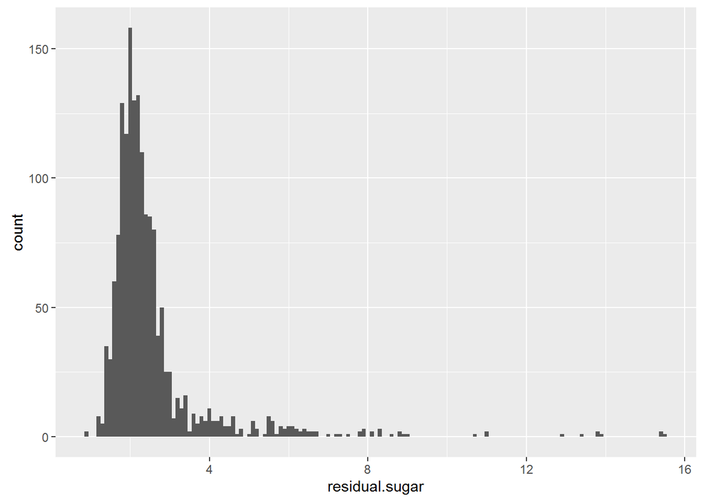

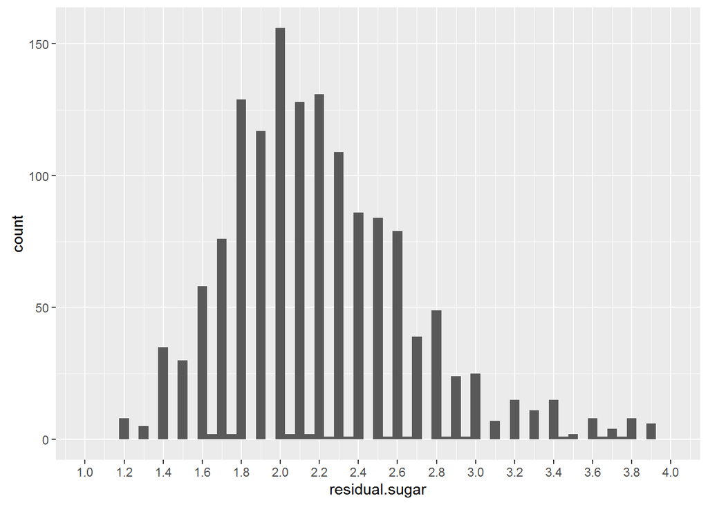

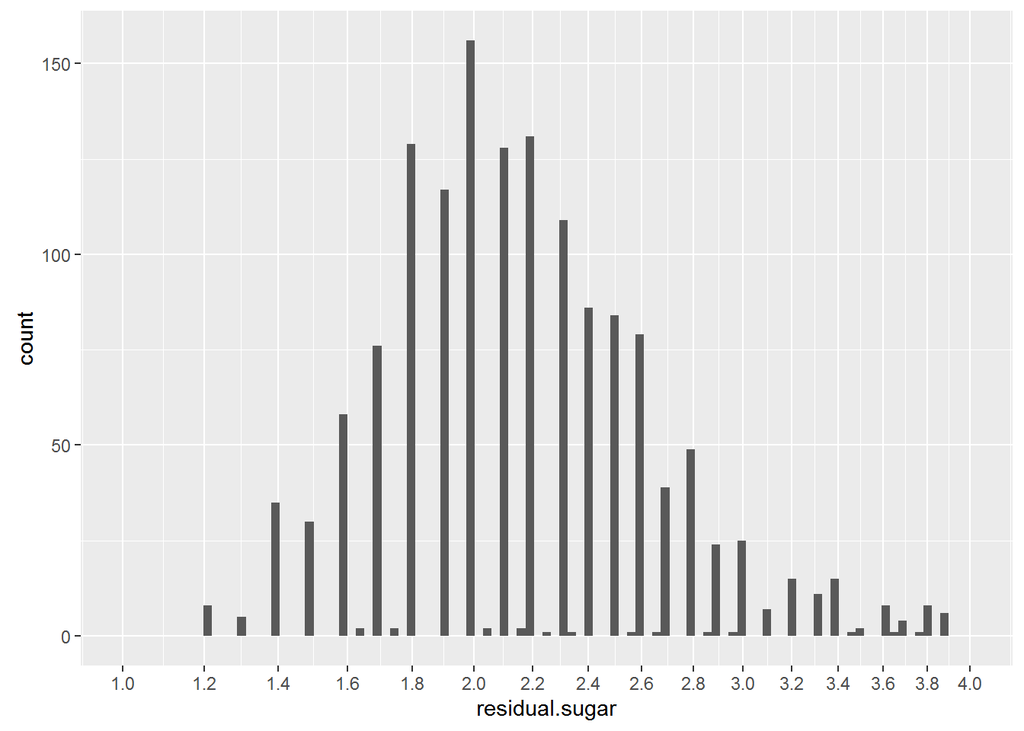

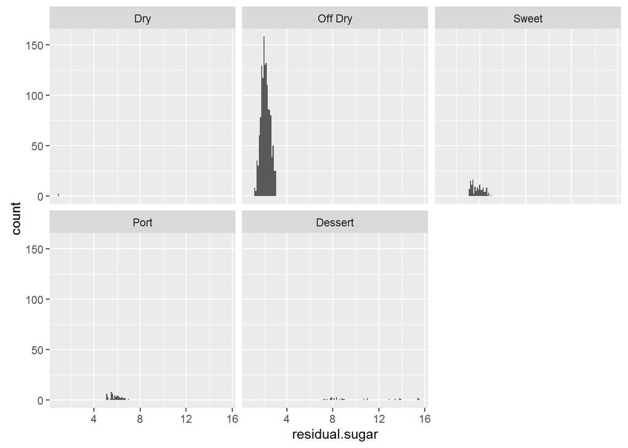

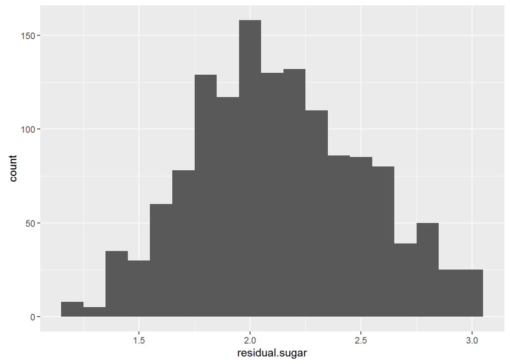

Residual sugars has a roughly normal distribution but with a substantial tail in the high end of the dist. Applying a square root scale looks to contract the values for a more normal curve.

Its not at all clear what unit this variable uses, some quick goggling typically give residual sugar units in g/L but with typical values of 2-20 g/L this does not fit the data distribution. It appears residual sugar here is expressed as a percentage (wt % most likely) with values ranging from the driest reds at 0.9 % to dessert wines at 15%.

Creating a category for wine types based on sweetness might be appropriate her for separating different styles in future analysis, a basic categorization was found below and modified for this data set (this is a bit crude and Dry wines are looking suspiciously sparse but will at least be useful to subset out the outliers).

Source of residual sugars information: https://www.winecurmudgeon.com/residual-sugar-in-wine-with-charts-and-graphs/

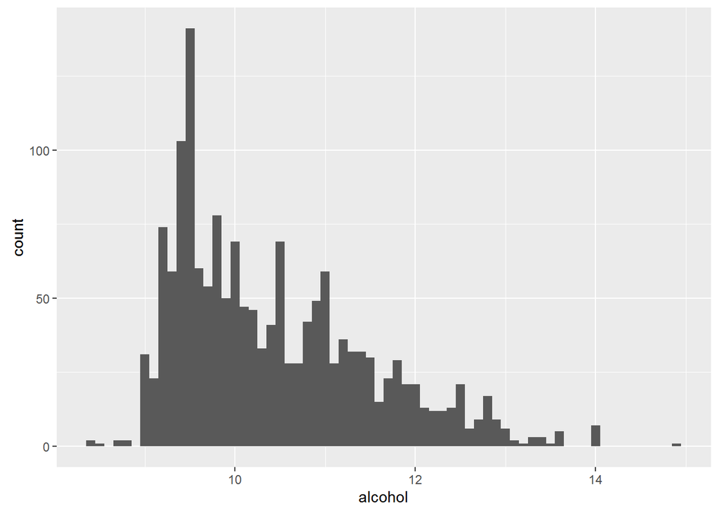

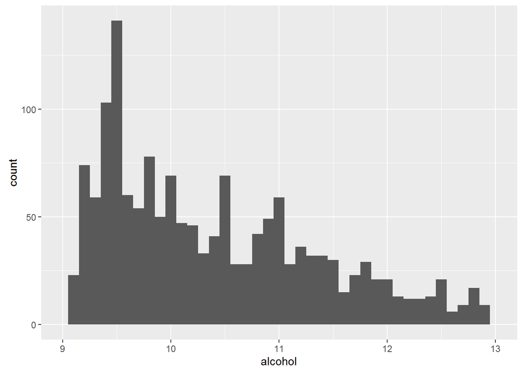

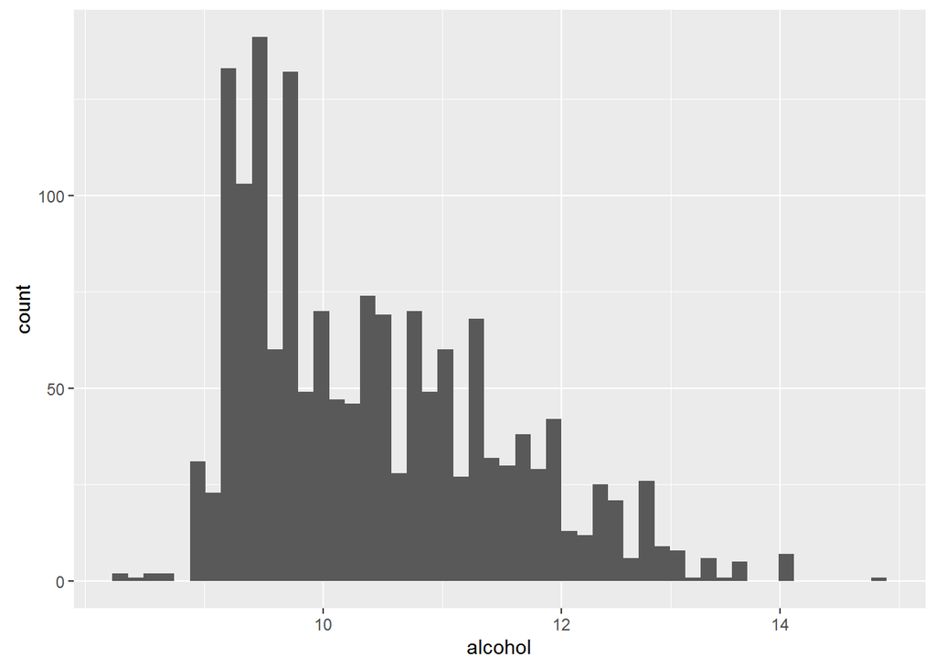

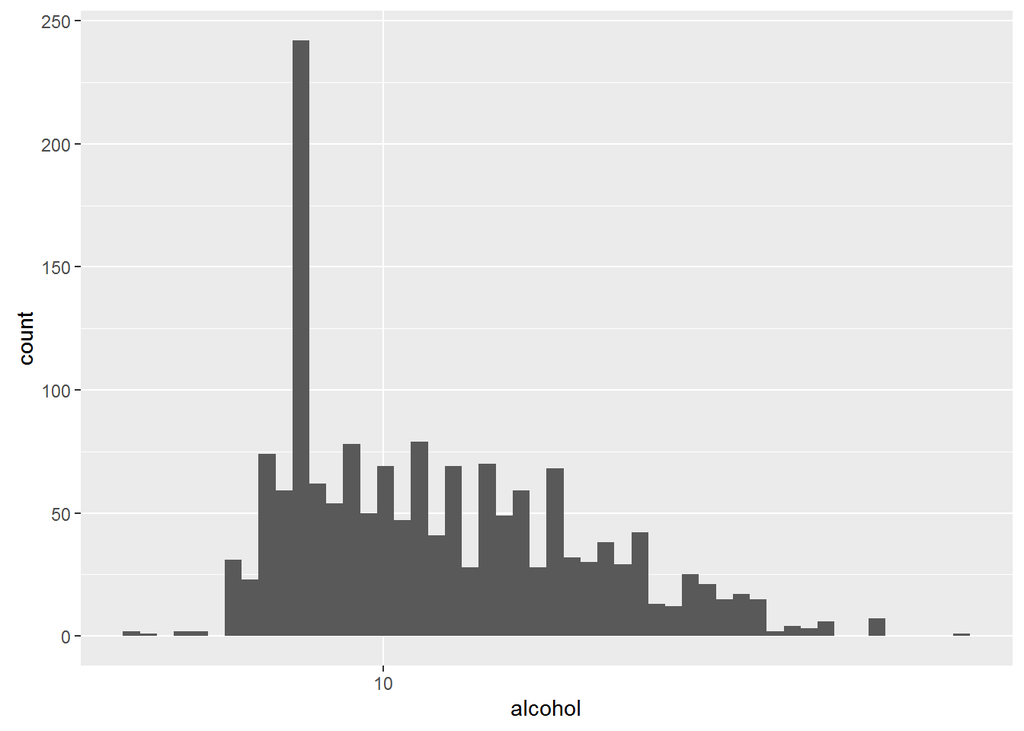

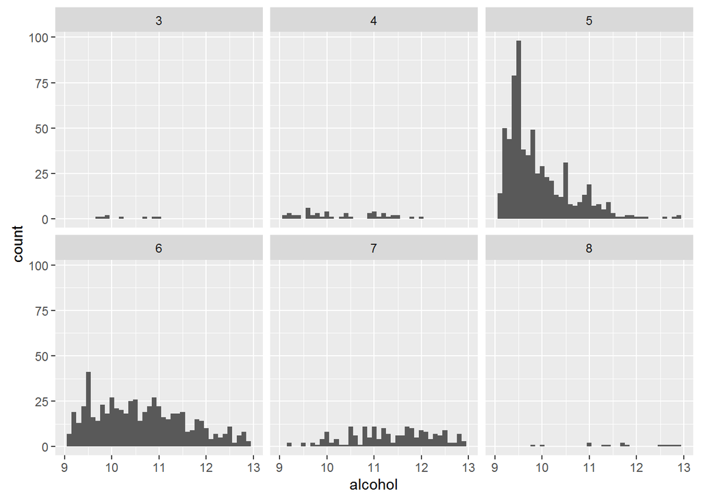

The distribution of alcohol content of the wines follow an unusual distribution with limited wines below 9 % volume and then a very long fat tail up to about 13 %. Applying several scales to this histogram failed to provide any new insights nor did breaking the histograms out by quality bin. The peak at 9.5 % is most apparent in Q = 5 wines. Its possible that this distribution reflects the most popular styles of mid range wines and gives more information about trends wine consumption rather than quality.

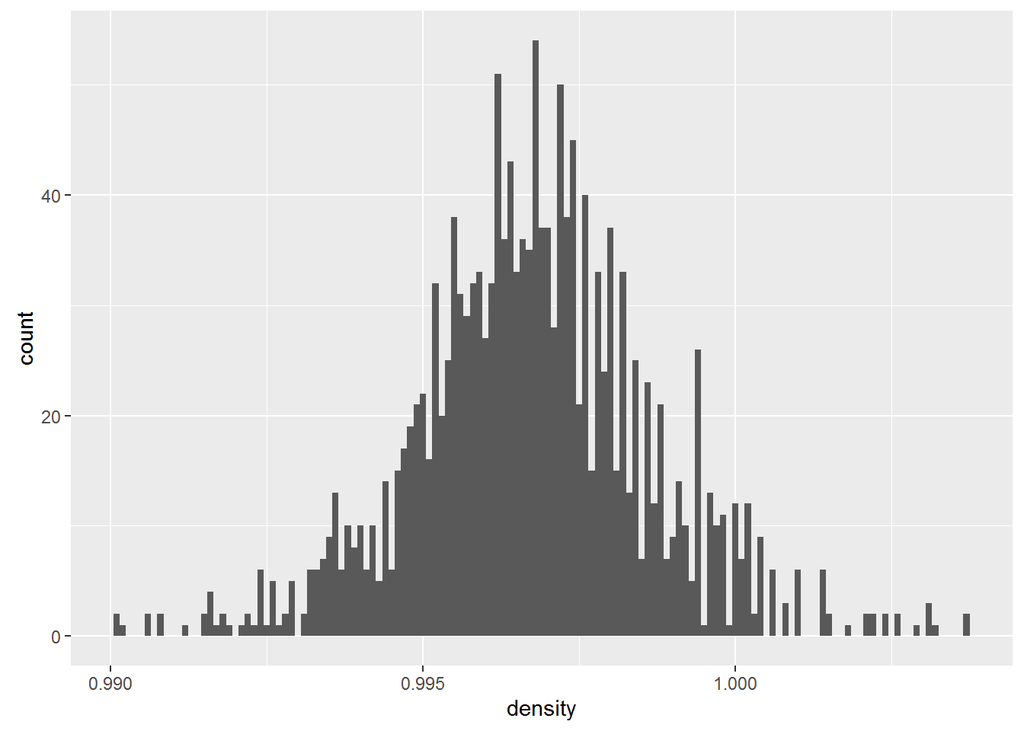

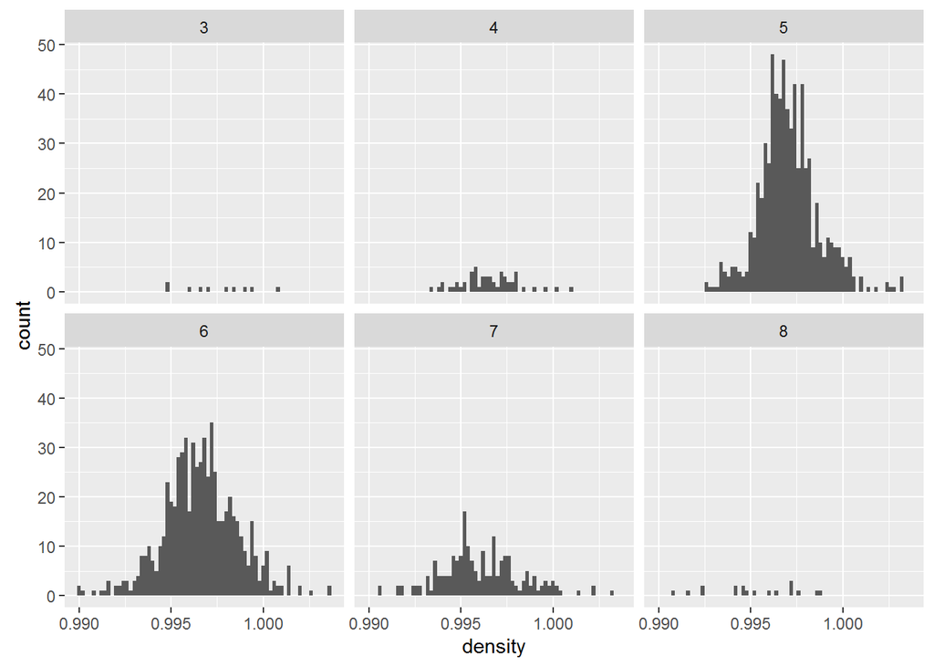

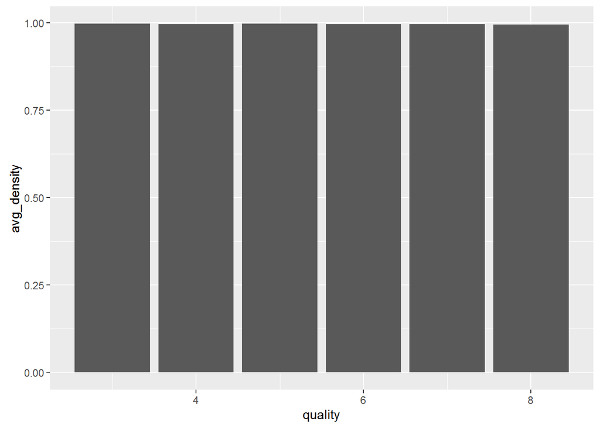

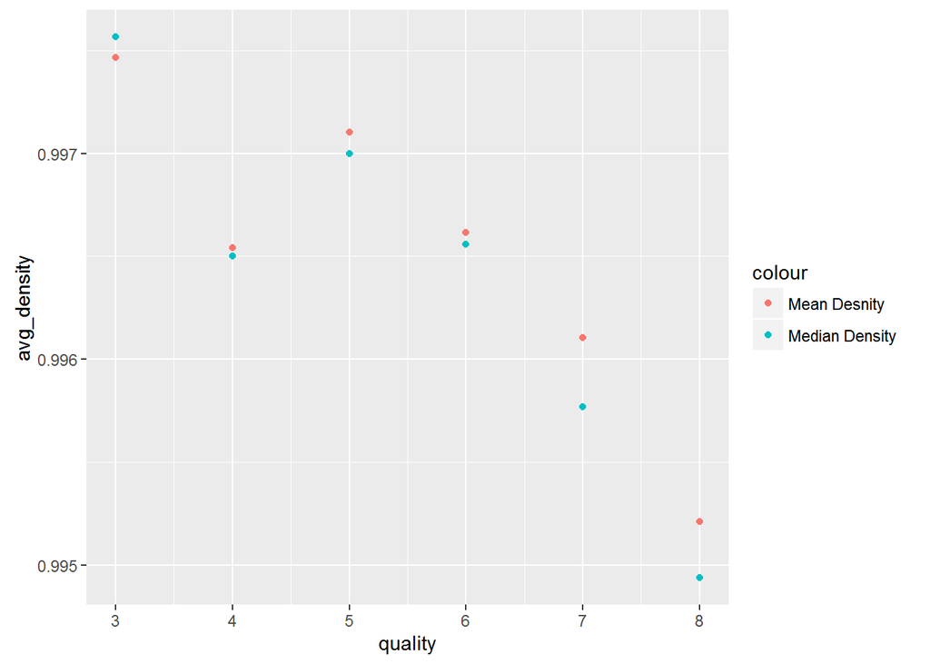

Density appears normally distributed though splitting by quality seems to produce two slightly skewed distribution for the most populated wine qualities (5 and 6). Breaking the mean and median densities out by quality appears to show an overall downward trend in density for increasing quality.

```
##    Min. 1st Qu.  Median    Mean 3rd Qu.    Max.
##    4.60    7.10    7.90    8.32    9.20   15.90
```

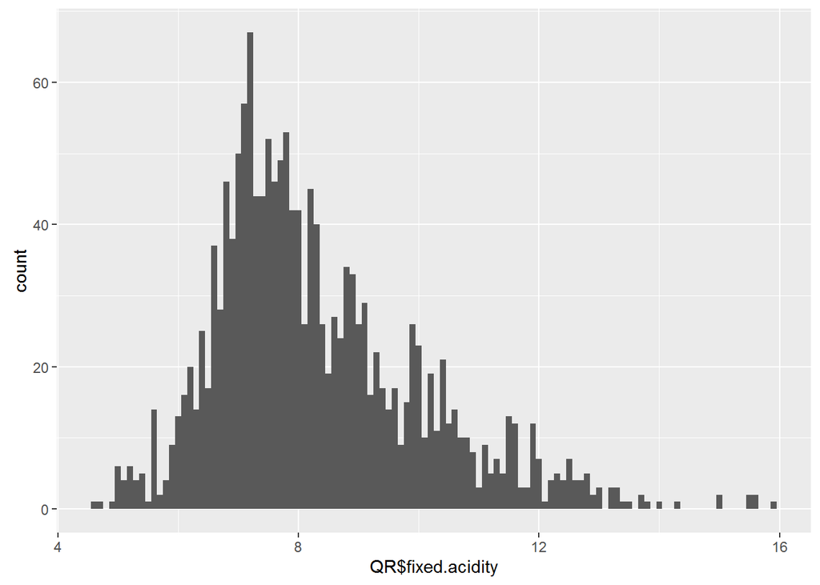

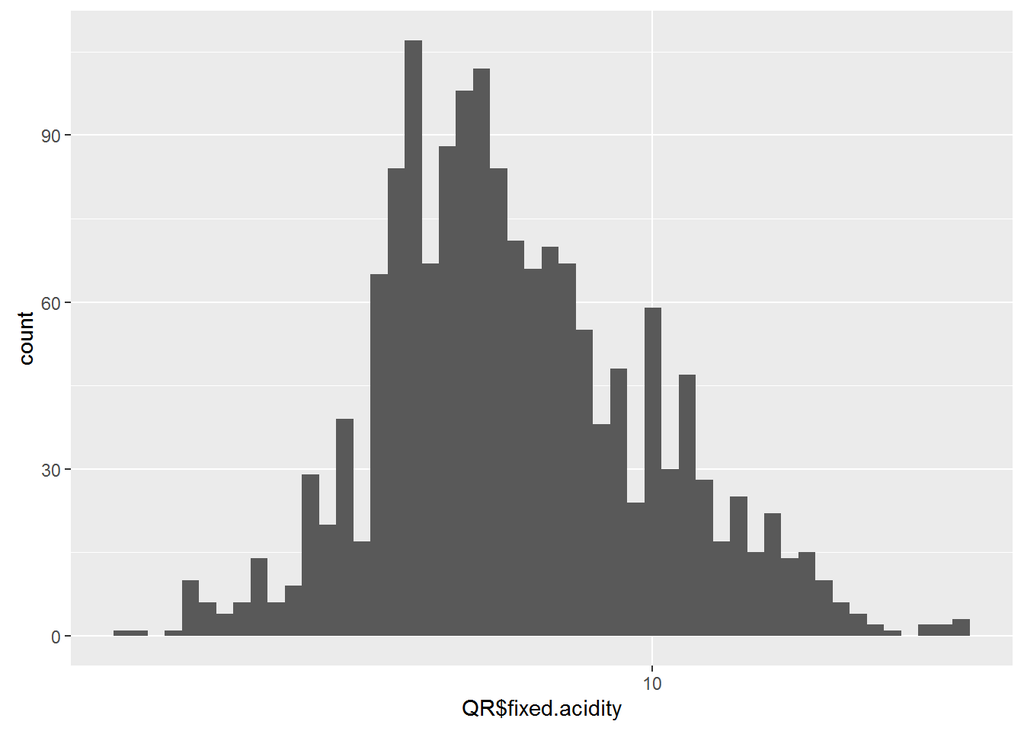

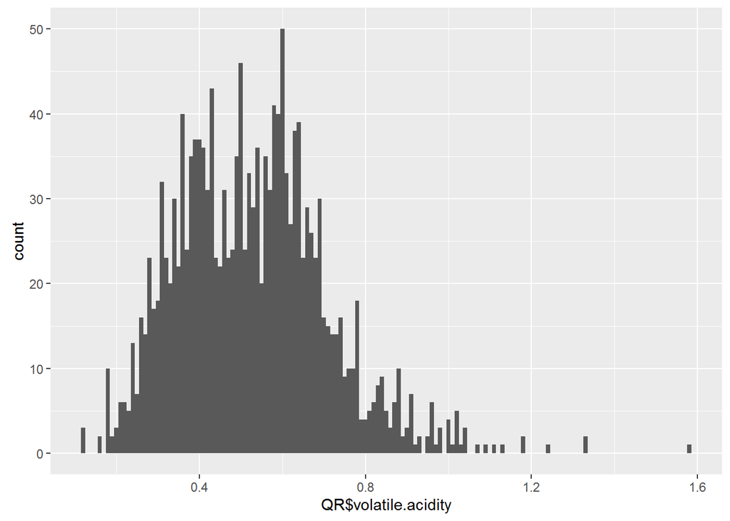

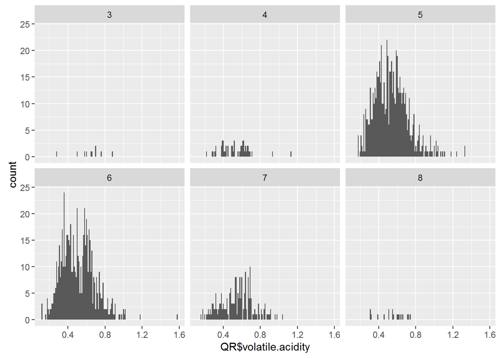

```
## [1] "Mean Volatile Acidity"
```

```
## # A tibble: 6 × 2
##   quality       avg
##     <int>     <dbl>
## 1       3 0.8845000
## 2       4 0.6939623
## 3       5 0.5770411
## 4       6 0.4974843
## 5       7 0.4039196
## 6       8 0.4233333
```

```
##         X fixed.acidity volatile.acidity citric.acid residual.sugar
## 127   127           8.2             1.33        0.00            1.7
## 128   128           8.1             1.33        0.00            1.8
## 673   673           9.8             1.24        0.34            2.0
## 1300 1300           7.6             1.58        0.00            2.1
##      chlorides free.sulfur.dioxide total.sulfur.dioxide density   pH
## 127      0.081                   3                   12 0.99640 3.53
## 128      0.082                   3                   12 0.99640 3.54
## 673      0.079                  32                  151 0.99800 3.15
## 1300     0.137                   5                    9 0.99476 3.50
##      sulphates alcohol quality Sweetness
## 127       0.49    10.9       5   Off Dry
## 128       0.48    10.9       5   Off Dry
## 673       0.53     9.5       5   Off Dry
## 1300      0.40    10.9       3   Off Dry
```

Fixed acidity has a long tail for higher acidity and applying new scales doesn’t seem to resolve this.

Volatile acidity is also complex with a possible bimodality hidden in the distribution and a long tail for higher acidity. Breaking the distributions out by quality the bimodality becomes slightly more pronounced.

Information found online (http://waterhouse.ucdavis.edu/whats-in-wine/volatile-acidity) sugggests volitle acidity as a measure of wine spoilage as it largely corresponds to acetic acid levels in the wine. The mean volatile acidity for the lowest quality of wines is higher than that of better quality wines but this relation breaks down for the higher quality wines.

Interestingly there are wines in the data set with volatile acidity beyond the US legal limit listed

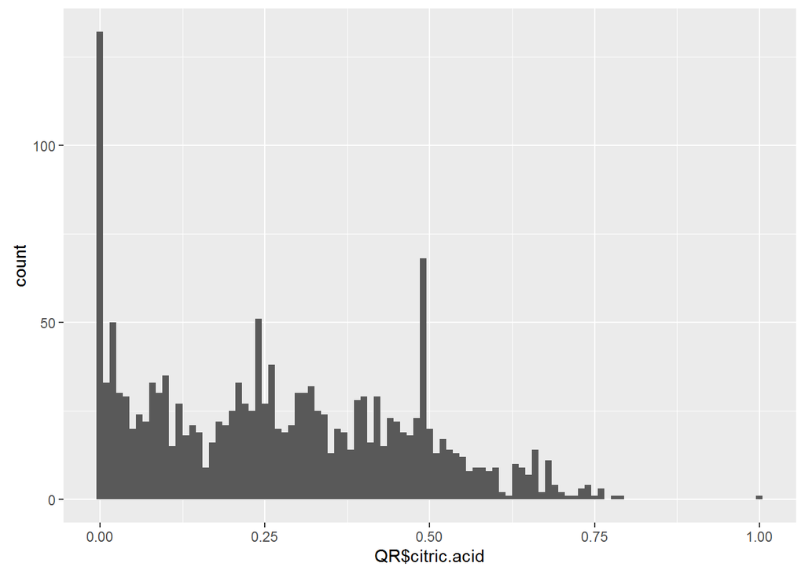

```
##            n
## 1 0.08255159
```

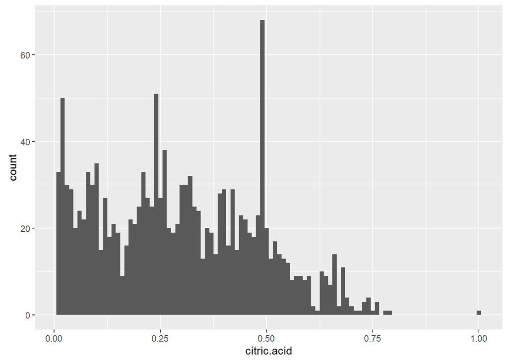

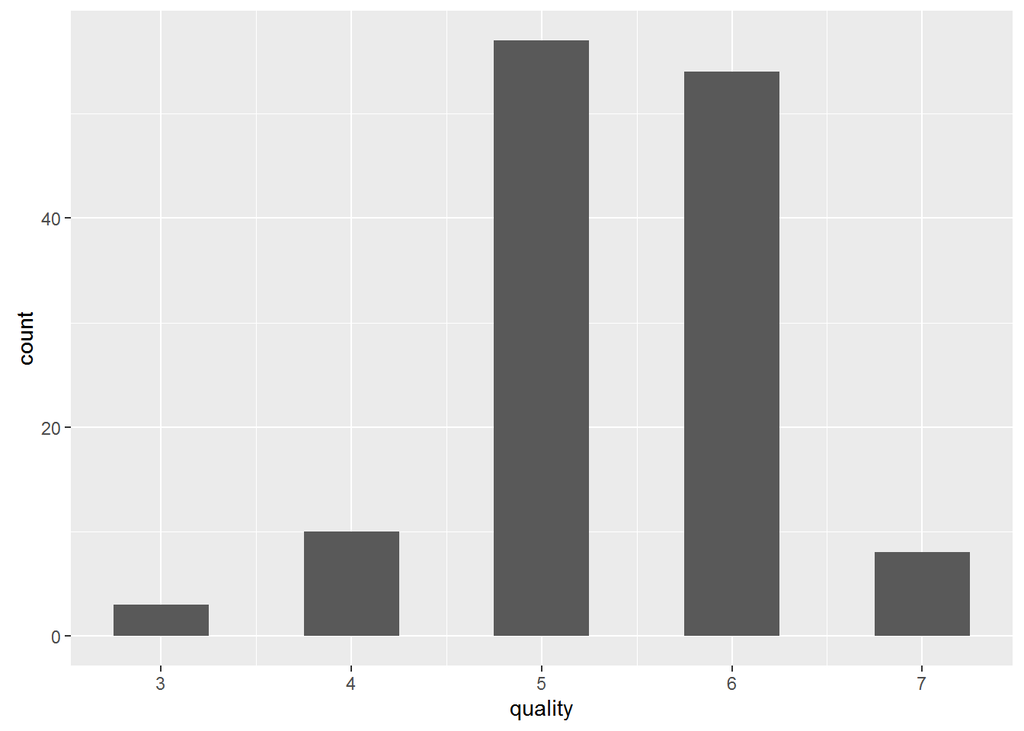

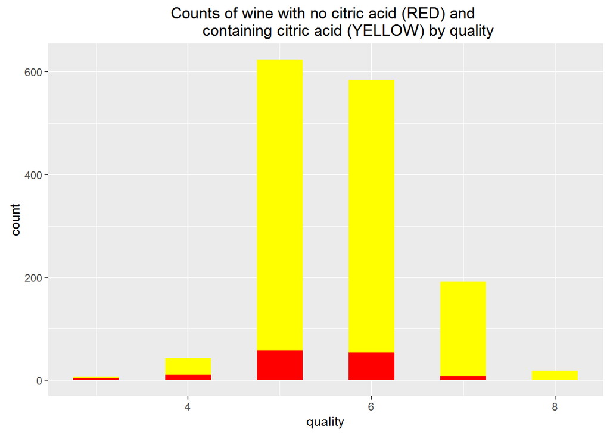

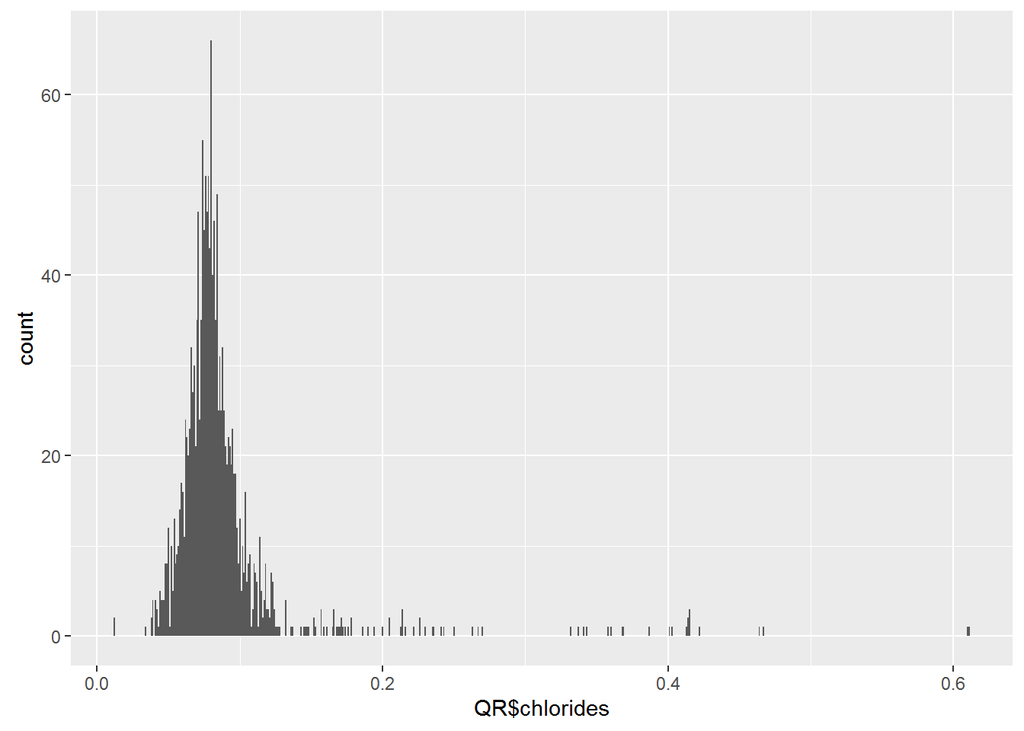

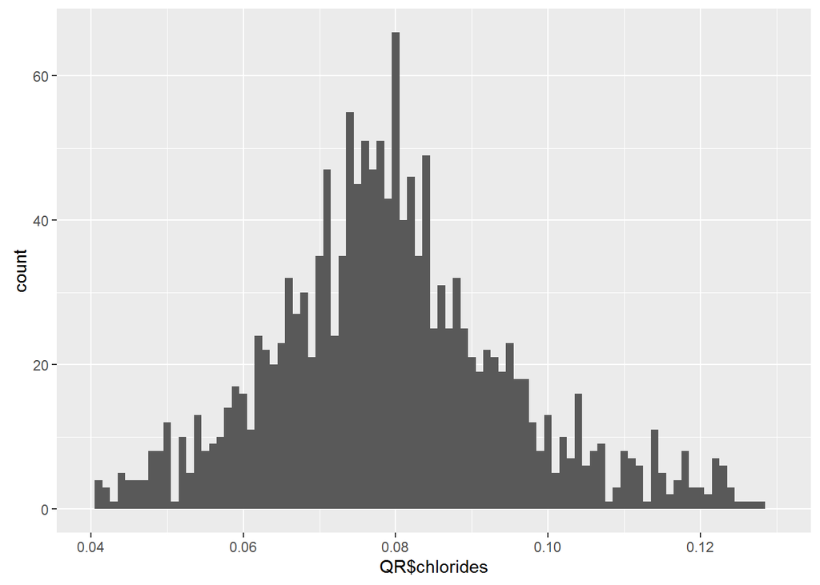

```
##    Min. 1st Qu.  Median    Mean 3rd Qu.    Max.
## 0.04100 0.07000 0.07850 0.07949 0.08800 0.12800
```

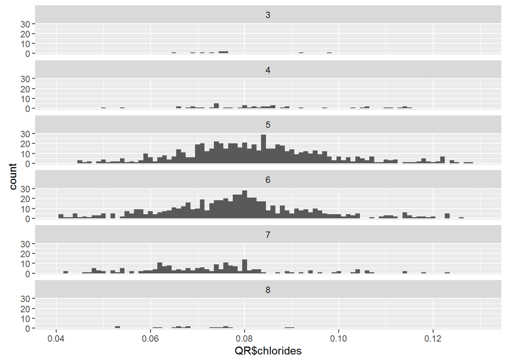

```
## Observations: 1
## Variables: 14
## $ X                    <dbl> -0.1960803
## $ fixed.acidity        <dbl> 0.05215707
## $ volatile.acidity     <dbl> 0.1372031
## $ citric.acid          <dbl> 0.6102384
## $ residual.sugar       <dbl> 0.3249878
## $ chlorides            <dbl> 3.804413
## $ free.sulfur.dioxide  <dbl> 0.01552478
## $ total.sulfur.dioxide <dbl> 0.04975434
## $ density              <dbl> 0.3543852
## $ pH                   <dbl> -0.755478
## $ sulphates            <dbl> 1.349306
## $ alcohol              <dbl> -0.6938383
## $ quality              <dbl> -0.344012
## $ Sweetness            <dbl> NA
```

The chlorides content looks to have a normal distribution near the bottom of the scale but this is obscured by a very long tail of outliers. Shrinking the limits gives a more normal distribution centered around a mean of ~ 0.08.